# ROP meta-analysis

Aman Josan

30/03/22

### Type 1 ROP

All studies which considered type 1 ROP

| study | treatment-Bevacizumab | treatment-Ranibizumab | treatment-Aflibercept | treatment-Laser | study design | no. Eyes-Bevacizumab | no. Eyes-Ranibizumab | no. Eyes-Aflibercept | no. Eyes-Laser | no. responders-Bevacizumab | no. responders-Ranibizumab | no. responders-Aflibercept | no. responders-Laser |
| --- | --- | --- | --- | --- | --- | --- | --- | --- | --- | --- | --- | --- | --- |
| Demir 2019 | IVB(0.625 mg/0.025ml) | NA | NA | laser photocoagulation | r | 57 | 0 | 0 | 64 | 48 | NA | NA | 47 |
| Murakami 2021 | IVB (0.625 mg/0.025 ml) | NA | NA | laser | r | 24 | 0 | 0 | 28 | 20 | NA | NA | 28 |
| Hwang 2015 | IVB (0.625mg/0.025ml) | NA | NA | laser PRP (32) | r | 22 | 0 | 0 | 32 | 19 | NA | NA | 31 |
| Kong 2015 | IVB (0.625mg/0.025mL) | NA | NA | laser | r | 43 | 0 | 0 | 37 | 40 | NA | NA | 33 |
| Isaac 2015 | IVB (0.625mg/0.025ml) | NA | NA | laser | r | 23 | 0 | 0 | 22 | 23 | NA | NA | 21 |
| Mintz Hittner 2011 | IVB(0.625mg/0.025mL) | NA | NA | laser | RCT | 140 | 0 | 0 | 146 | 134 | NA | NA | 114 |
| Chen 2018a | IVB(0.625 mg) | NA | NA | diode laser photocoag | r | 29 | 0 | 0 | 20 | 1 | NA | NA | 18 |
| Mueller 2017 | IVB 0.625 mg (0.025 ml) | NA | NA | laser | r | 74 | 0 | 0 | 34 | 64 | NA | NA | 34 |
| Nicoara 2016 | IVB 0.625 mg (0.025 ml) | NA | NA | laser | r | 34 | 0 | 0 | 12 | 31 | NA | NA | 10 |
| Zhang 2017 | NA | IVR (0.3mg/0.03mL) | NA | laser | RCT | 0 | 50 | 0 | 50 | NA | 24 | NA | 48 |
| Chmielarz-Czarnocinska 2021 | NA | IVR (0.25 mg/0.025 m) | NA | laser | r | 0 | 120 | 0 | 226 | NA | 40 | NA | 180 |
| Leng 2018 | NA | IVR (0.25mg) | NA | laser | r | 0 | 24 | 0 | 98 | NA | 14 | NA | 56 |
| Chan 2016 | NA | IVR (0.25 mg/0.025 ml) | NA | laser | r | 0 | 8 | 0 | 10 | NA | 2 | NA | 8 |
| Ekinci 2020 | NA | NA | IVA 1mg/0.025mL(24) | laser(27) | r | 0 | 0 | 24 | 27 | NA | NA | 18 | 25 |
| Riazi-esfahani 2021 | IVB(0.625mg/0.025mL) | NA | IVA 1mg/0.025mL | NA | r | 865 | 0 | 24 | 0 | 831 | NA | 10 | NA |
| Sukgen 2019 | NA | IVR 0.25 mg/0.025 mL (54) | IVA 1 mg/0.025 mL,(72) | NA | r | 0 | 54 | 72 | 0 | NA | 42 | 66 | NA |
| Suren 2022 | IVB(0.625mg/0.025mL) | IVR(0.25mg/0.025mL) | IVA 1 mg/0.025 mL | NA | r | 54 | 77 | 56 | 0 | 46 | 58 | 48 | NA |
| Kabatas 2017 | IVB(0.625mg/0.025mL) | IVR(0.25mg/0.025mL) | NA | laser | r | 24 | 12 | 0 | 72 | 22 | 10 | NA | 62 |
| Ling 2020 | IVB(0.625mg/0.025mL) | IVR(0.25mg/0.025mL) | NA | laser | r | 231 | 48 | 0 | 61 | 208 | 38 | NA | 50 |
| Gunay 2016 | IVB (0.625mg/0.025mL) | IVR (0.25/0.025mL) | NA | laser | r | 107 | 44 | 0 | 113 | 101 | 38 | NA | 113 |
| Wong 2015 | IVB (0.625 mg/0.025 mL) | IVR ( 0.25 mg/0.025 mL) | NA | NA | r | 4 | 6 | 0 | 0 | 4 | 3 | NA | NA |
| Kang 2018 | IVB (0.625 mg/0.025 mL) | IVR (0.2 mg/0.02 mL) | NA | NA | r | 101 | 52 | 0 | 0 | 93 | 45 | NA | NA |
| Chen 2018b | IVB (0.625 mg/0.025 mL) | IVR (0.25 mg/0.025 mL) | NA | NA | r | 40 | 26 | 0 | 0 | 36 | 26 | NA | NA |
| Erol 2015 | IVB (0.625mg) | IVR (0.25mg) | NA | NA | r | 21 | 15 | 0 | 0 | 19 | 11 | NA | NA |
| Kimyon 2018 | IVB (0.625mg/0.025mL) | IVR (0.25mg/0.025mL) | NA | NA | r | 40 | 28 | 0 | 0 | 36 | 26 | NA | NA |
| Lyu 2019 | NA | IVR (0.25mg/0.025mL) | NA | laser | r | 0 | 17 | 0 | 10 | NA | 15 | NA | 7 |
| Mori 2020 | IVB (0.625mg/0.025mL) | NA | NA | laser | r | 26 | 0 | 0 | 106 | 14 | NA | NA | 98 |
| Zayek 2021 | IVB (0.625mg/0.025mL) | NA | NA | laser | r | 122 | 0 | 0 | 170 | 102 | NA | NA | 166 |
| Fleck 2022 | NA | IVR (0.2 mg) | NA | laser | post-hoc analysis of RCT | 0 | 146 | 0 | 138 | NA | 106 | NA | 104 |
| FIREFLEYE 2022 | NA | NA | IVA 0.4 mg (0.01 mL) | laser | RCT | 0 | 0 | 150 | 76 | NA | NA | 139 | 69 |

Number of studies=30 (after unsuitable studies removed)

Number of patients=4686

## Event count data and conventional meta-analysis of proportions

### Transform data (Dichotomous data)

Here we define the number of responders as the number of patients treated minus the number of patients requiring retreatment. Hence the measure of treatment effectiveness we are applying is the number of patients requiring no retreatment.

Since we are dealing with raw prevalence (or event rate) data (i.e. sample size and number of treatment responders) rather than correlations (i.e. Pearsons r for treatment correlations) we need to perform a meta-analysis of proportions. Most meta-analysis in the literature deal with randomised control trials with correlations and p-values.

The proportion of treatment responders ($p$) is given by

$$\begin{align}
p = \frac{x}{n}
\end{align}$$

where $x$ is the number of treatment responders in a study and $n$ is the total number treated with that treatment in the study.

Again data is quite skewed (as is normally the case in number of event data), hence use double arcsine transformation for the conventional meta-analysis again.

Lets look at a forest plot of each study treatment to see the effect size and variances (here, weights given to each study are inversely related to the variances).

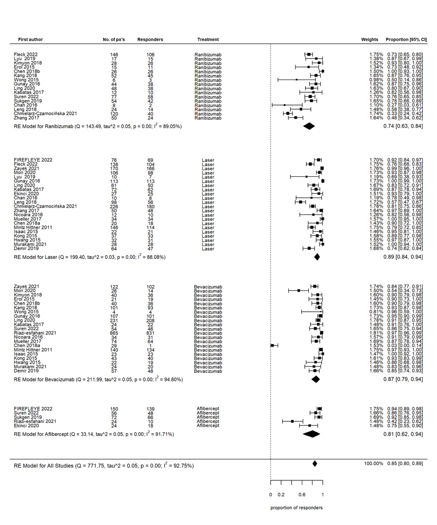

Hence, overall, taking all treatments into account, a predicted 85% (80%-89%) of patients with type 1 ROP would likely require no retreatment.

(Note, Q, tau, and $I$ and the p-values here refer to the statistical significance of the presence of heterogeneity).

Look at individual treatment statistics by pooling all studies for each treatment and performing four separate meta-analyses using a random effects model.

As we are most interested in a comparison of treatment effects we need to perform a Bayesian analysis (see later).

Avastin

| capture.output.metafor_Avastin_res. |
| --- |
| Random-Effects Model (k = 21; tau^2 estimator: REML) |
| tau^2 (estimated amount of total heterogeneity): 0.0546 (SE = 0.0194) |
| tau (square root of estimated tau^2 value): 0.2336 |
| I^2 (total heterogeneity / total variability): 94.80% |
| H^2 (total variability / sampling variability): 19.23 |
| Test for Heterogeneity: |
| Q(df = 20) = 211.9915, p-val < .0001 |
| Model Results: |
| estimate se zval pval ci.lb ci.ub |
| 1.1848 0.0542 21.8657 <.0001 1.0786 1.2910 *** |
| — |
| Signif. codes: 0 ‘**’ 0.001 ’**’ 0.01 ’’ 0.05 ‘.’ 0.1 ’ ’ 1 |

```
   pred  ci.lb  ci.ub  pi.lb  pi.ub
 0.8704 0.7861 0.9377 0.4272 1.0000
```

Lucentis

| capture.output.metafor_Lucentis_res. |
| --- |
| Random-Effects Model (k = 16; tau^2 estimator: REML) |
| tau^2 (estimated amount of total heterogeneity): 0.0464 (SE = 0.0203) |
| tau (square root of estimated tau^2 value): 0.2155 |
| I^2 (total heterogeneity / total variability): 89.05% |
| H^2 (total variability / sampling variability): 9.13 |
| Test for Heterogeneity: |
| Q(df = 15) = 143.4925, p-val < .0001 |
| Model Results: |
| estimate se zval pval ci.lb ci.ub |
| 1.0244 0.0593 17.2868 <.0001 0.9082 1.1405 *** |
| — |
| Signif. codes: 0 ‘**’ 0.001 ’**’ 0.01 ’’ 0.05 ‘.’ 0.1 ’ ’ 1 |

```
   pred  ci.lb  ci.ub  pi.lb  pi.ub
 0.7404 0.6272 0.8406 0.2973 1.0000
```

Eylea

| capture.output.metafor_Eylea_res. |
| --- |
| Random-Effects Model (k = 5; tau^2 estimator: REML) |
| tau^2 (estimated amount of total heterogeneity): 0.0481 (SE = 0.0380) |
| tau (square root of estimated tau^2 value): 0.2192 |
| I^2 (total heterogeneity / total variability): 91.71% |
| H^2 (total variability / sampling variability): 12.06 |
| Test for Heterogeneity: |
| Q(df = 4) = 33.1368, p-val < .0001 |
| Model Results: |
| estimate se zval pval ci.lb ci.ub |
| 1.1070 0.1037 10.6698 <.0001 0.9036 1.3103 *** |
| — |
| Signif. codes: 0 ‘**’ 0.001 ’**’ 0.01 ’’ 0.05 ‘.’ 0.1 ’ ’ 1 |

```
   pred  ci.lb  ci.ub  pi.lb  pi.ub
 0.8070 0.6200 0.9437 0.3450 1.0000
```

Laser

| capture.output.metafor_Laser_res. |
| --- |
| Random-Effects Model (k = 22; tau^2 estimator: REML) |
| tau^2 (estimated amount of total heterogeneity): 0.0268 (SE = 0.0101) |
| tau (square root of estimated tau^2 value): 0.1638 |
| I^2 (total heterogeneity / total variability): 88.08% |
| H^2 (total variability / sampling variability): 8.39 |
| Test for Heterogeneity: |
| Q(df = 21) = 199.4026, p-val < .0001 |
| Model Results: |
| estimate se zval pval ci.lb ci.ub |
| 1.2192 0.0388 31.4051 <.0001 1.1431 1.2953 *** |
| — |
| Signif. codes: 0 ‘**’ 0.001 ’**’ 0.01 ’’ 0.05 ‘.’ 0.1 ’ ’ 1 |

```
   pred  ci.lb  ci.ub  pi.lb  pi.ub
 0.8926 0.8377 0.9383 0.6062 1.0000
```

As with zone 1 ROP, the above stats show summary effect sizes (all have significance p<0.05 under the model results heading).

Magnitude of effect sizes:

- Avastin effect size (predicted proportion): 87.0% [78.6 - 93.8] …… (n=2081)
- Lucentis effect size (predicted proportion): 74.0% [62.7 - 84.1] …… (n=727)
- Eylea effect size (predicted proportion): 80.7% [62.0 - 94.4] ….. (n=326)
- Laser effect size (predicted proportion): 89.3% [83.8 - 93.8] ….. (n=1552)

The above for Avastin predicts that treatment with Avastin would likely result in approx 87% of patients with type 1 ROP requiring no retreatment.

Now we break down which studies contributed most to the overall result above and display with a Baujat plot

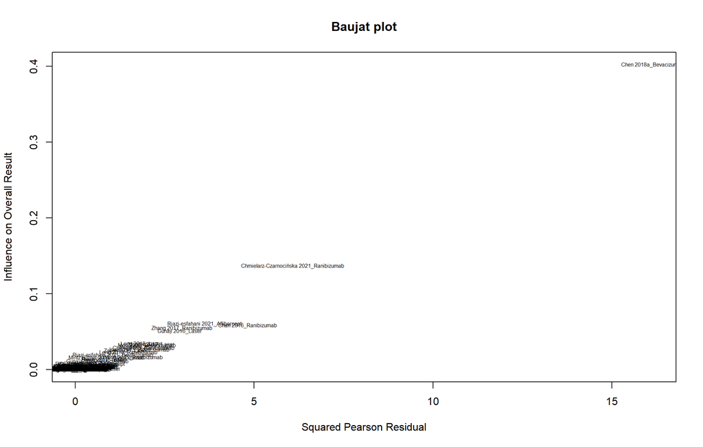

Here we can see a potential outliers. Perhaps worth looking at chen 2018a (Avastin) study to see if any irregularities in study methods here also. - Emer checked and no irregularities found. Seems like a genuine outlier.

Recall this is a conventional frequentist meta-analysis and so does not compare relative effect sizes of treatments. Each number should be taken in isolation and is predicted based on the study results for that treamtment alone. The percentages should not be used to pit one drug against another as the study sample sizes and variances are not equal between treatments.

In summary: P-values do not provide information regarding effect size. In Bayesian analysis, however, alternative models are compared resulting in relative effect sizes.

## Heterogeneity

Again the stats above show there is significant (p<0.05) heterogeneity in studies reporting Avastin, Lucentis, Eylea and Laser outcomes suggesting the studies in each subgroup are significantly different from each other.

In summary: Significant heterogeneity implies there is no common single true effect size associated with a treatment across different studies of the same drug and that the differences between study results are beyond those attributable to chance/random sampling. Hence, we assume that there is not only one true effect size, but a distribution of true effect sizes. This distribution is simulated later using a Bayesian analysis.

## Funnel plot

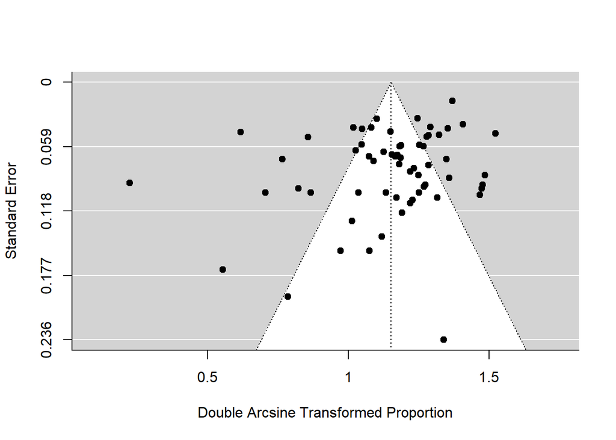

```
Regression Test for Funnel Plot Asymmetry

Model:     mixed-effects meta-regression model
Predictor: standard error

Test for Funnel Plot Asymmetry: z = -1.5476, p = 0.1217
Limit Estimate (as sei -> 0):   b = 1.2471 (CI: 1.1148, 1.3794)
```

Again visually there is no obvious asymmetry and Egger’s regression test confirms that there is no significant asymmetry (p > 0.05).

So again it can be said from this funnel plot and Egger’s regression that there is no evidence of small study bias.

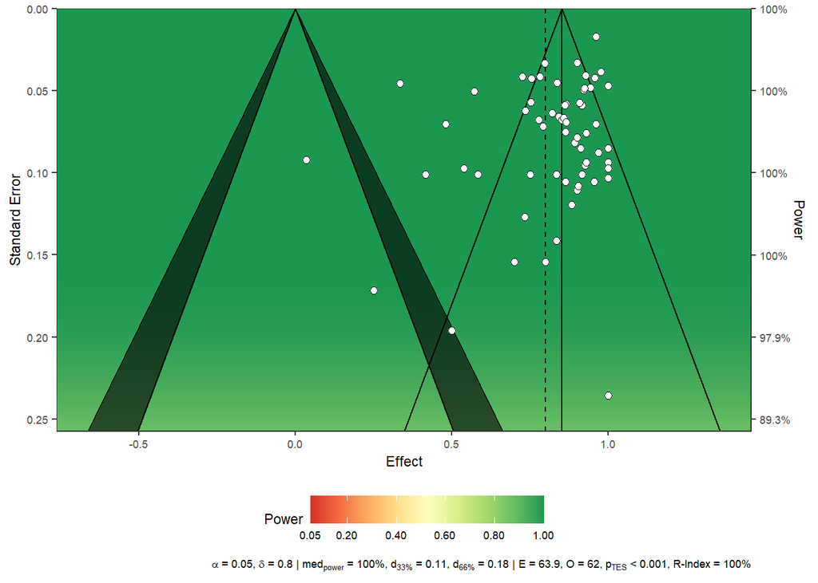

Once again all studies have extremely high power (92+ percent) giving us ample confidence that all statistically non-significant results are valid as statements of “no difference” rather than being due to insensitive/insufficient data.

## Bayesian network meta-analysis

### Summary of network

```
$Description
[1] "MTC dataset: Bayesian NMA"

$`Studies per treatment`
Aflibercept Bevacizumab       Laser Ranibizumab
          5          21          22          16

$`Number of n-arm studies`
2-arm 3-arm
   26     4

$`Studies per treatment comparison`
           t1          t2 nr
1 Aflibercept Bevacizumab  2
2 Aflibercept       Laser  2
3 Aflibercept Ranibizumab  2
4 Bevacizumab       Laser 14
5 Bevacizumab Ranibizumab  9
6       Laser Ranibizumab  9
```

Network plot (line thickness connecting nodes denotes the number studies for each comparison)

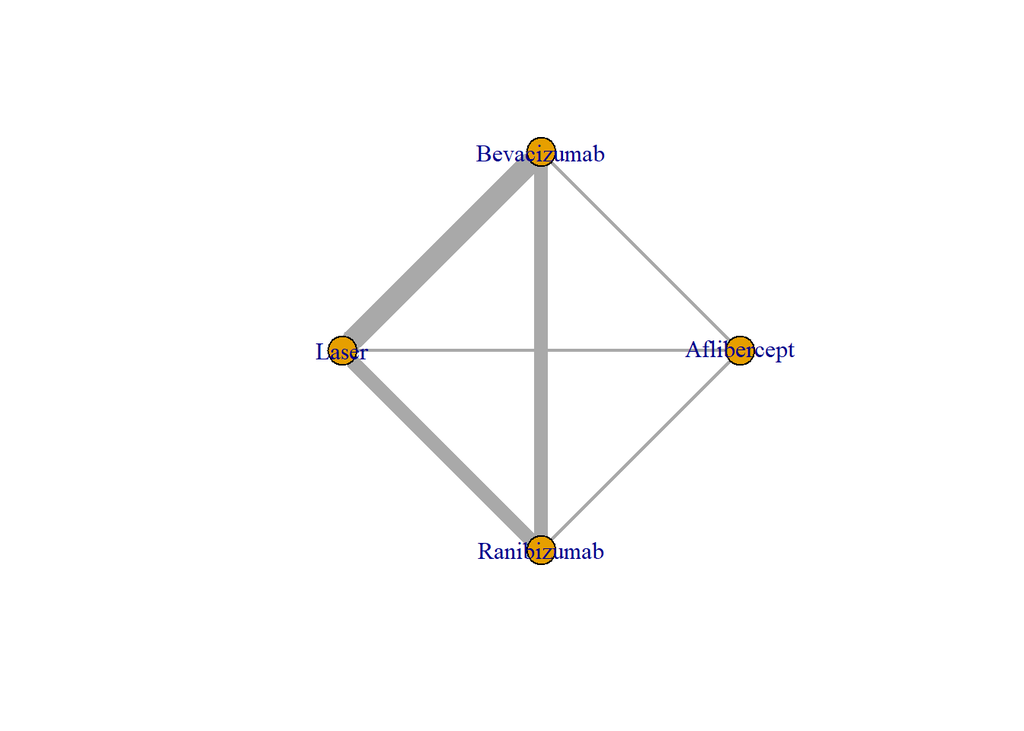

MCMC validation plots and inconsistency analysis performed. All is ok and no network inconsistencies are evident

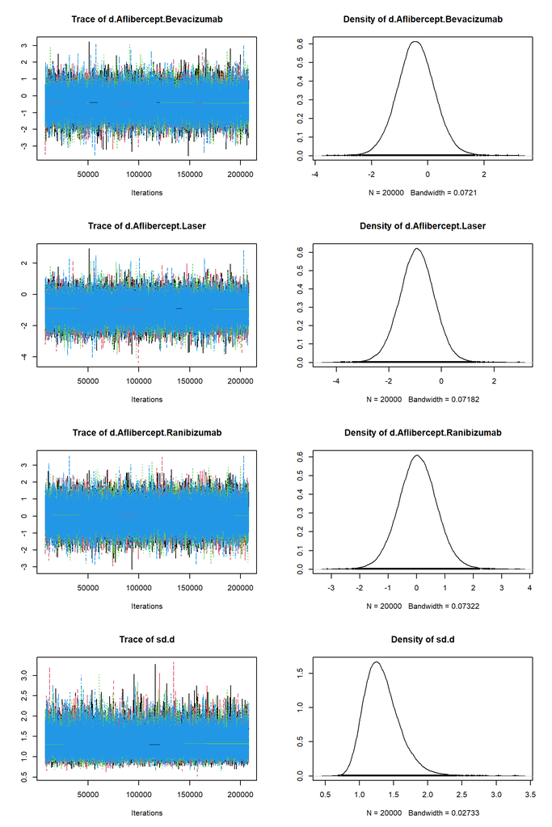

Apart from visual inspection of the trace plots, further validation in the form of a Gelman-Rubin-Brooks plots shows the Potential Scale Reduction Factor (PSRF) is within acceptable limits (<1.05) showing adequate MCMC chain convergence has been achieved (i.e. stable results)

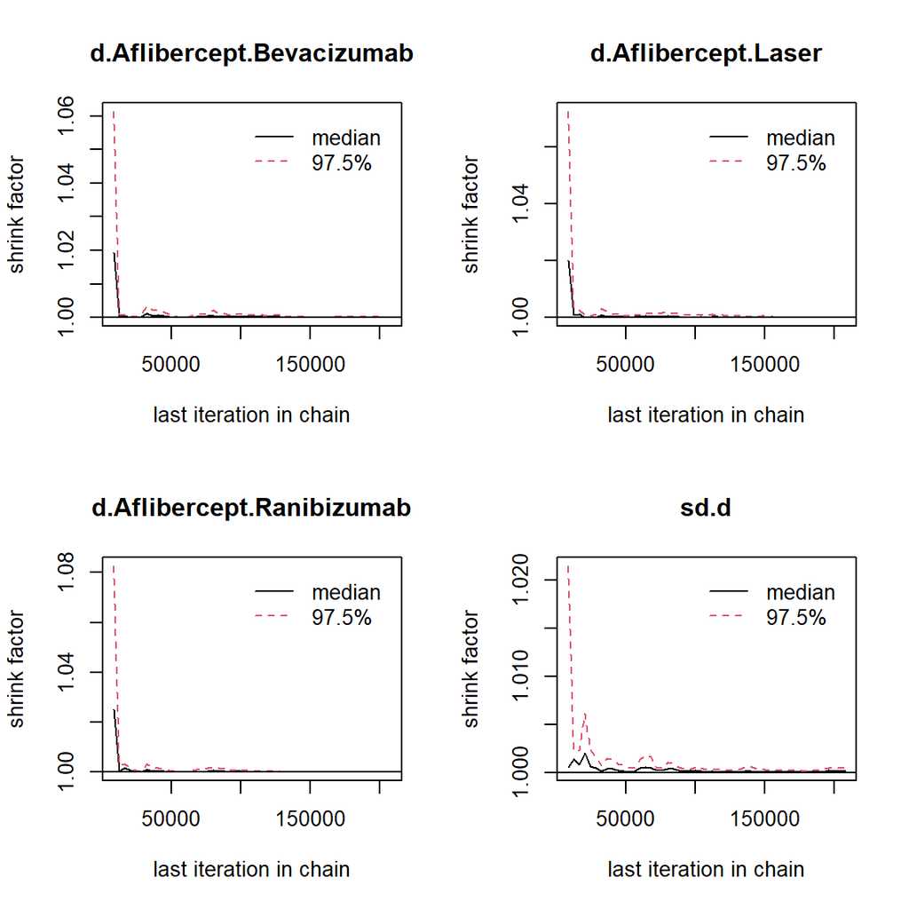

```
Potential scale reduction factors:

                          Point est. Upper C.I.
d.Aflibercept.Bevacizumab          1          1
d.Aflibercept.Laser                1          1
d.Aflibercept.Ranibizumab          1          1
sd.d                               1          1
```

```
[1] "PSRF = 1.0002"
```

# Summary of results of Bayesian network analysis:

## MCMC simulation summary

In the following analysis we are again using a risk ratio (or relative risk) as the measure of liklihood.

A summary of the MCMC simulation

```
Results on the Log Risk Ratio scale

Iterations = 8010:208000
Thinning interval = 10
Number of chains = 4
Sample size per chain = 20000

1. Empirical mean and standard deviation for each variable,
   plus standard error of the mean:

                             Mean     SD  Naive SE Time-series SE
d.Aflibercept.Bevacizumab -0.4173 0.6670 0.0023583       0.002945
d.Aflibercept.Laser       -0.9332 0.6640 0.0023476       0.002948
d.Aflibercept.Ranibizumab  0.0399 0.6750 0.0023864       0.002965
sd.d                       1.3331 0.2574 0.0009102       0.001118

2. Quantiles for each variable:

                             2.5%     25%      50%      75% 97.5%
d.Aflibercept.Bevacizumab -1.7240 -0.8552 -0.42224  0.01647 0.909
d.Aflibercept.Laser       -2.2529 -1.3656 -0.93107 -0.49723 0.362
d.Aflibercept.Ranibizumab -1.2924 -0.4032  0.03814  0.48199 1.380
sd.d                       0.9195  1.1508  1.30235  1.48120 1.921

-- Model fit (residual deviance):

     Dbar        pD       DIC
 68.72135  54.16336 122.88472

64 data points, ratio 1.074, I^2 = 8%
```

# Relative effect table

this is the main table of interest comparing all treatment options with results derived from direct and indirect methods:

```
Risk Ratio (95% CrI)

   Aflibercept    0.66 (0.18, 2.48) 0.39 (0.11, 1.44) 1.04 (0.27, 3.97)
1.53 (0.4, 5.61)     Bevacizumab    0.6 (0.28, 1.24)  1.58 (0.68, 3.62)
2.54 (0.7, 9.52)  1.66 (0.81, 3.61)       Laser       2.63 (1.19, 6.01)
0.96 (0.25, 3.64) 0.63 (0.28, 1.48) 0.38 (0.17, 0.84)    Ranibizumab
```

N.B.

Interpretation of Risk Ratio - ratio of probabilites (remember to inverse log above first)

- RR < 1: risk of requiring retreatment lower with treatment 1 than treatment 2
- RR = 1: risk of requiring retreatment the same between treatment 1 and treatment 2
- RR > 1: risk of requiring retreatment higher with treatment 1 than treatment 2

## Rankings

Rank probability to answer which treatment performs best

```
Rank probability; preferred direction = -1
                 [,1]      [,2]      [,3]      [,4]
Aflibercept 0.0709875 0.1753125 0.2945250 0.4591750
Bevacizumab 0.0701875 0.6054750 0.2654125 0.0589250
Laser       0.8532500 0.1283750 0.0172625 0.0011125
Ranibizumab 0.0055750 0.0908375 0.4228000 0.4807875
```

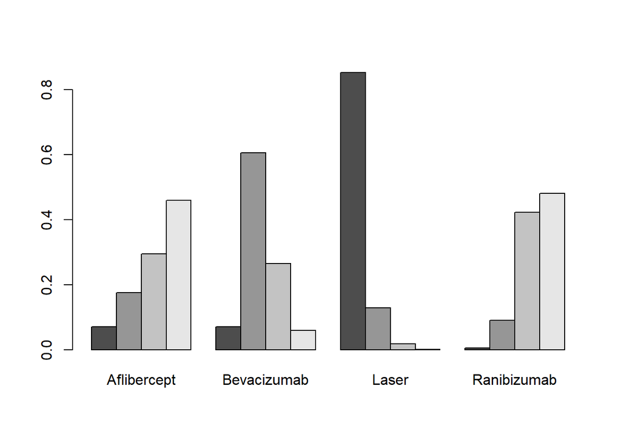

A rank plot illustrating empirical probabilities that each treatment is ranked 1st through 4th (left to right).

Laser is clear first in ranking here

Use surface under the cumulative ranking (SUCRA) measure to better quantify the probability rankings (takes ranking overlap into account)

```
Aflibercept Bevacizumab       Laser Ranibizumab
      0.286       0.562       0.945       0.207
```

This again suggests Laser is ranked as the most effective treatment (i.e. lowest risk ratio meaning lowest risk of requiring retreatment) according to the studies involving treatment for type 1 ROP. Here Avastin is ranked second, Eylea ranked third and Lucentis forth. Again these rankings are not very useful unless all differences between treatment modalities are statistically significant which they are not in this case. Hence best not to use SUCRA.

We can look at another forest plot to visualise results by comparing treatments.

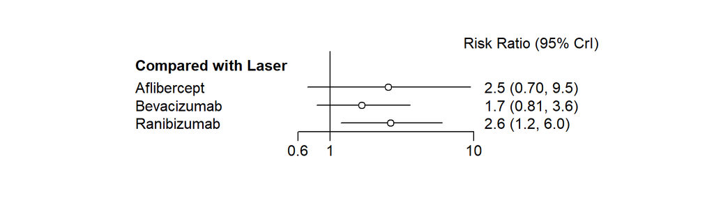

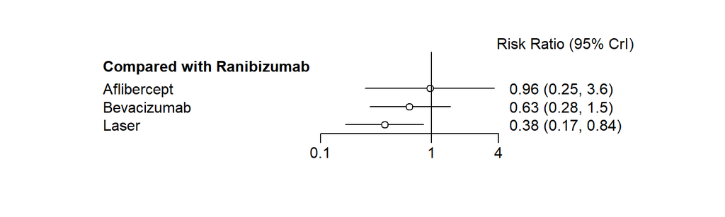

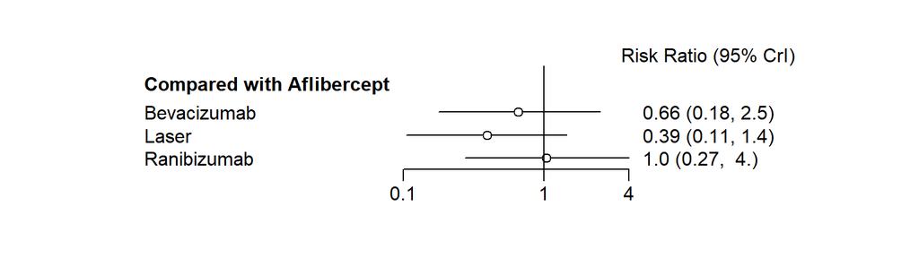

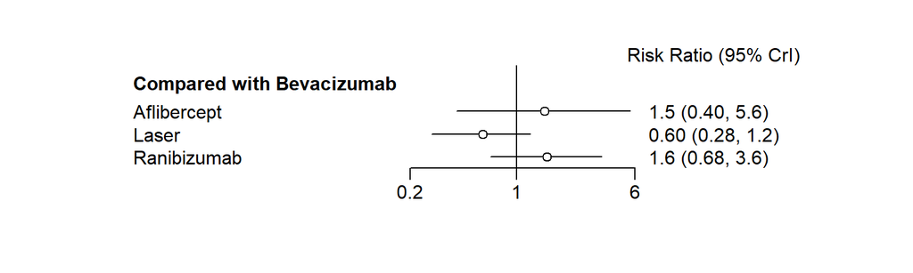

Recall lower risk ratio here is better (i.e. lower risk of requiring retreatment)

Here, we have one comparison that reaches statistical significance. Treatment with Laser has statistically significantly less risk of requiring subsequent retreatment than after Lucentis treatments. All other comparisons found no evidence of statistically significant differences.

Here we can say with significance:

- Treatment with Laser is associated with 62% less risk of requiring retreatment than treatment with Lucentis for type 1 ROP. This does not take potential moderators into account. We shall look at this later.

N.b. Avastin is no longer statistically significantly different to Laser